# Exercise Chapter 1

Tobias Hugentobler

09.03.2023

## Exercise 1

In this exercise, we consider 95%-confidence intervals for the true mean of a uniform distribution.

### a.

Generate a sample of 30 observations from the standard uniform distribution and calculate a Student confidence interval for the true mean $\mu$. Interpret it.

```r
ci <- function(x, se, alpha=0.05, df, method="norm"){

  mu_hat <- mean(x)
  if(method == "student"){
    conf_int = c(mu_hat + -1:1*se*qt(1-alpha/2, degreesOfFreedom))
  } else if(method == "norm") {
    conf_int = c(mu_hat + -1:1*se*qnorm(1-alpha/2))
  }

  names(conf_int) <- c("lci", "estimate", "uci")
  return(conf_int)
}
```

```r
set.seed(145)

nObs = 30
alpha = 0.05
degreesOfFreedom = nObs-1
x = runif(nObs)
mu_hat <- mean(x)
se_hat <- sd(x) / sqrt(nObs)

conf_int <- ci(x, se_hat, df=degreesOfFreedom, method="student")
conf_int
```

```
##       lci  estimate       uci
## 0.4592289 0.5723531 0.6854773
```

### b.

Calculate the Bootstrap estimate of the standard error and compare it with the usual estimate of the standard error. Plot a histogram of the Bootstrap replications.

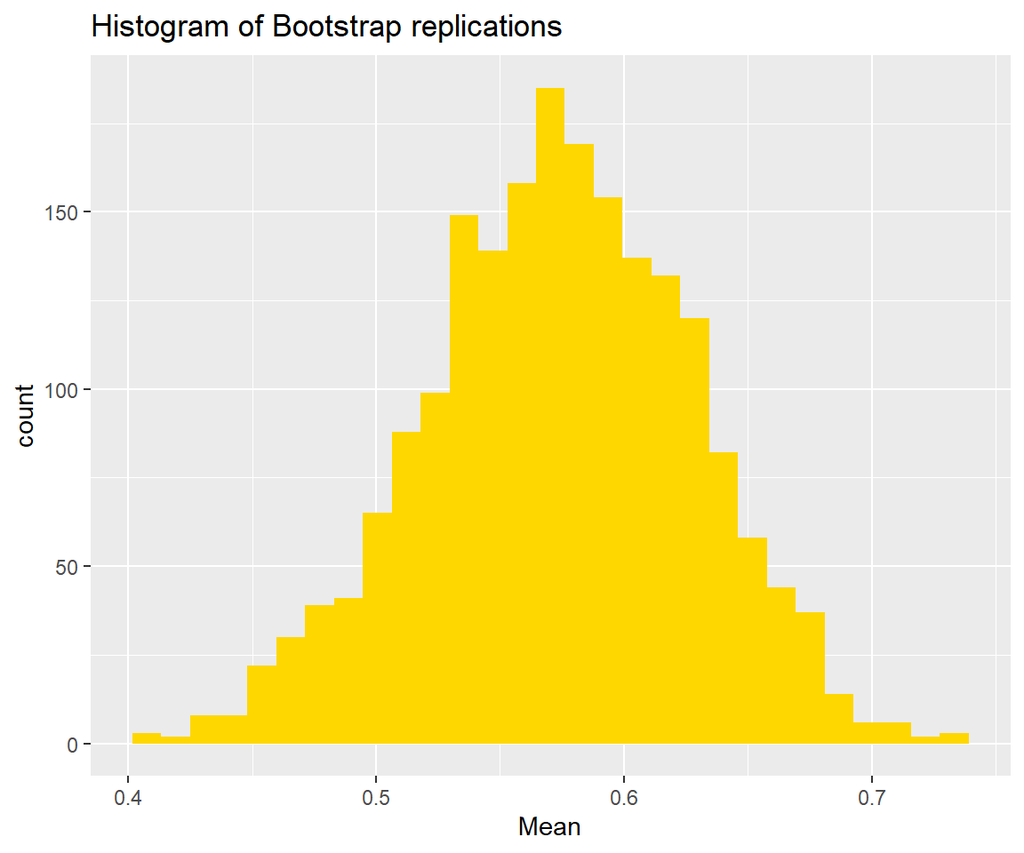

```r
library(ggplot2)
nBoot = 2000
boot <- replicate(nBoot, mean(sample(x, replace = TRUE)))

se_boot = sd(boot)

ggplot(data.frame(Mean = boot), aes(x = Mean)) +
  geom_histogram(fill = "gold", bins = 29) +
  ggtitle("Histogram of Bootstrap replications")
```

### c.

Use the `plot_stability()` function of the lecture notes to figure out after how many Bootstrap samples the Bootstrap estimate of the standard error would stabilize.

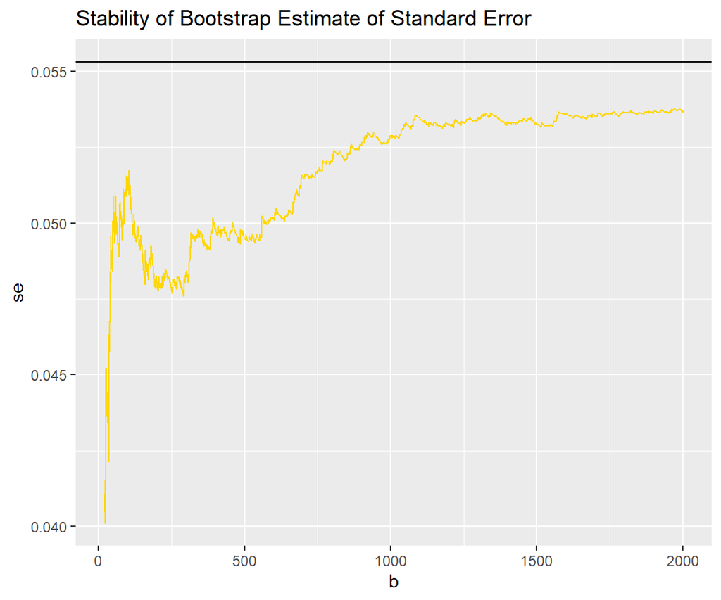

```r
plot_stability <- function(x) {  # x is the vector of Bootstrap replications
  df <- data.frame(x = x, b = 1:length(x))
  df$se <- sapply(df$b, function(i) sd(x[1:i]))  # "cumsd"

  ggplot(subset(df, b >= 20), aes(b, se)) +
    geom_line(color = "gold") +
    ggtitle("Stability of Bootstrap Estimate of Standard Error")
}
# stabilisation happens after 1500
plot_stability(boot) +
  geom_hline(yintercept = sd(x) / sqrt(nObs))  # Estimated standard error of the mean
```

### d.

Calculate a standard normal Bootstrap CI and a percentile Bootstrap CI for $\mu$. Compare with the interval from 1a.

```r
conf_int_norm = ci(x, se_boot, method="norm")
conf_int_norm
```

```
##       lci  estimate       uci
## 0.4670849 0.5723531 0.6776213
```

```r
conf_int
```

```
##       lci  estimate       uci
## 0.4592289 0.5723531 0.6854773
```

## Exercise 2

Consider the two samples $y_1 = 1, 2, \dots, 21$ and $y_2 = 1, 2, \dots, 51$.

```r
y_1 = 1:21
y_2 = 1:51
```

### a.

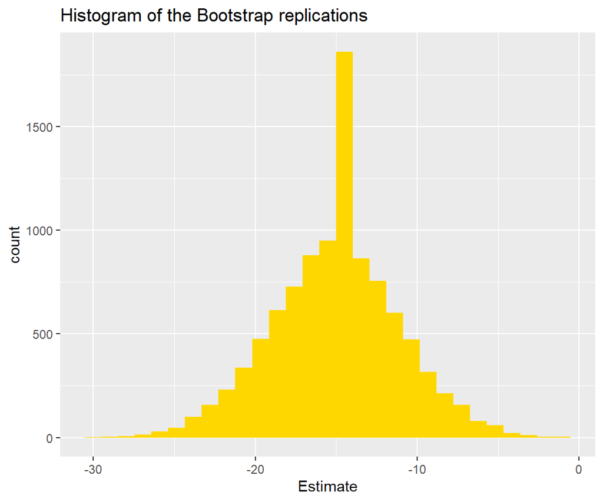

```r
estimator <- function(y1, y2) {
  median(y1) - median(y2)
}

boot <- replicate(
  9999,
  estimator(
    sample(y_1, replace = TRUE),
    sample(y_2, replace = TRUE)
  )
)

ggplot(data.frame(Estimate = boot), aes(x = Estimate)) +
  geom_histogram(fill = "gold", bins = 29) +
  ggtitle("Histogram of the Bootstrap replications")
```

```r
quantile(boot, c(0.025, 0.975))
```

```
##  2.5% 97.5%
##   -23    -7
```

Since 0 isn’t in the confidence interval, we can drop the null hypothesis that the medians of the two samples is the same (difference = 0)

### b.

Calculate a standard normal Bootstrap CI for $\theta$. Compare the two solutions.

```r
CI = estimator(y_1, y_2) + c(-1, 1) * qnorm(0.975) * sd(boot)
names(CI) <- c("2.5%", "97.5%")
CI
```

```
##       2.5%      97.5%
## -23.073427  -6.926573
```

The percentile method gives us integer values and the standardnormal method gives real numbers back. But if rounded they are the samecand give the same conclusion.

## Exercise 3

For the situation in Exercise 1, use simulation to estimate real coverage probabilities of the Student CI and the two types of Bootstrap CIs. What do you observe?

```r
nSim = 1000
nObs = 30
alpha = 0.05
degreesOfFreedom = nObs-1

is_ok <- function(ci, theta = log(2)) {
  (ci[1] <= theta) & (ci[3] >= theta)
}


result <- array(
  dim = c(3, nSim),
  dimnames = list(c("student", "boot_norm", "boot_quantile"), NULL)
)

if(FALSE){
  system.time({
    pb <- txtProgressBar(max = nSim, style = 3)
    for(i in 1:nSim) {

      x = runif(nObs)
      mu_hat <- mean(x)
      se_hat <- sd(x) / sqrt(nObs)
      boot <- replicate(9999, mean(sample(x, replace = TRUE)))

      result["student", i] <- is_ok(ci(x, se_hat, df=degreesOfFreedom, method="student"), theta = 0.5)
      result["boot_norm", i] <- is_ok(ci(x, sd(boot), method="norm"), theta = 0.5)
      result["boot_quantile", i] <- is_ok(quantile(boot, c(0.025, 0.5, 0.975), names = FALSE), theta = 0.5)
      setTxtProgressBar(pb, i)
    }
  })
} else {
  result <- readRDS("./ci_mean.rds")
}

(coverage_probs <- apply(result, 1, FUN = mean))
```

```
##       student     boot_norm boot_quantile
##         0.943         0.924         0.927
```

```r
library(tidyverse)
df <- coverage_probs %>%
  data.frame() %>%
  rownames_to_column(var = "type")
head(df)
```

|  | type | . |
| --- | --- | --- |
| 1 | student | 0.943 |
| 2 | boot_norm | 0.924 |
| 3 | boot_quantile | 0.927 |

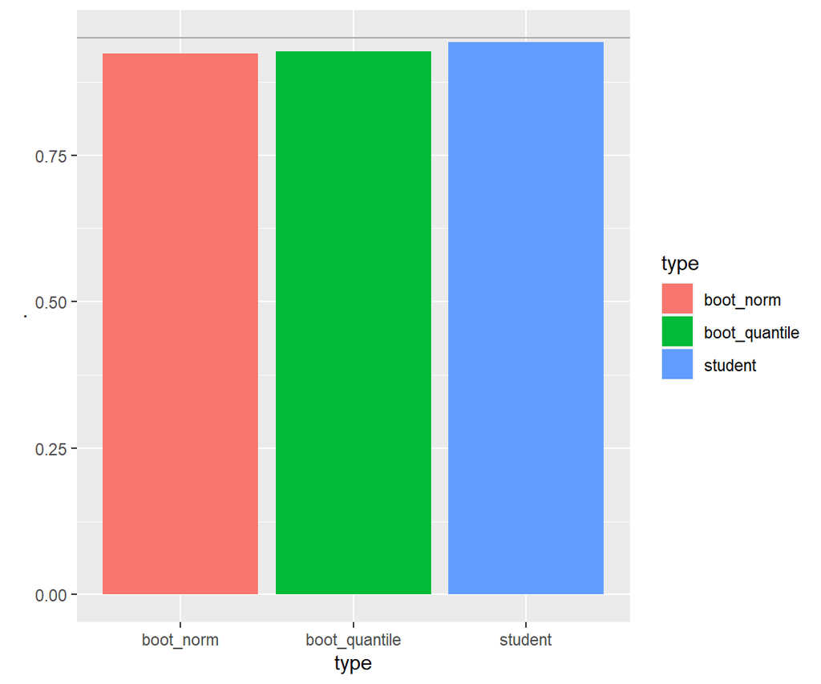

```r
df %>%
  ggplot() +
    geom_bar(mapping = aes(x = type, y = ., fill = type), stat = 'identity') +
    geom_hline(yintercept = 0.95, color = "darkgrey")
```

## Exercise 4

Here, we study a test on Spearman’s rank correlation. a. What is Spearman’s rank correlation? b. Write a function `spearman_test2(x, y, B = 10000)` that calculates a one-sided permutation p value for the null hypothesis of no positive monotonic association. I.e., you want to show the alternative hypothesis that the true rank correlation is positive. c. Use a simulated example to compare with the corresponding p values from the “coin” package, and also using `stats::cor.test(x, y, method = "s", method = "greater")`.

## Exercise 5

In the situation of Exercise 4: Use simulation to compare your approach with `stats::cor.test()` regarding… a. … Type 1 error? (Work with independent normal random variables) b. … power? (Work with dependent normal random variables). c. How do you interpret your result?